# Homewok 1

Jonathan Dale

#### Question 1:

The data sets here consists of applications for admission to graduate study at the University of California, Berkeley for the Fall 1973. “Admission.csv” contains university level admission status and “Original_Admissions_Data.csv” contains admissions by each department.

1. Using GGplot create an appropriate graphic to show the university-level Admissions. (Hint: Female and male applications admitted and rejected (stacked bar plot (2 bars), admitted and rejected broken down by % male/female.) (Use Admissions.csv).

```r
library(ggplot2)
setwd("~/Mason/2026/STAT-515-002/homework/hw1/")
admissions = read.csv("Admission.csv", header = TRUE)

# Lets do some initial descriptive analysis on the admissions data
dim(admissions) # View dimensions
```

```
## [1] 4 4
```

```r
str(admissions) # View the structure
```

```
## 'data.frame':    4 obs. of  4 variables:
##  $ Gender: chr  "Male" "Female" "Male" "Female"
##  $ Admit : chr  "Admitted" "Admitted" "Rejected" "Rejected"
##  $ Freq  : int  1158 557 1493 1278
##  $ Prop  : num  0.675 0.324 0.539 0.461
```

```r
head(admissions) # View the first few rows
```

|  | Gender | Admit | Freq | Prop |
| --- | --- | --- | --- | --- |
| 1 | Male | Admitted | 1158 | 0.675 |
| 2 | Female | Admitted | 557 | 0.324 |
| 3 | Male | Rejected | 1493 | 0.539 |
| 4 | Female | Rejected | 1278 | 0.461 |

```r
summary(admissions) # View a summary
```

```
##     Gender             Admit                Freq           Prop
##  Length:4           Length:4           Min.   : 557   Min.   :0.3240
##  Class :character   Class :character   1st Qu.:1008   1st Qu.:0.4268
##  Mode  :character   Mode  :character   Median :1218   Median :0.5000
##                                        Mean   :1122   Mean   :0.4998
##                                        3rd Qu.:1332   3rd Qu.:0.5730
##                                        Max.   :1493   Max.   :0.6750
```

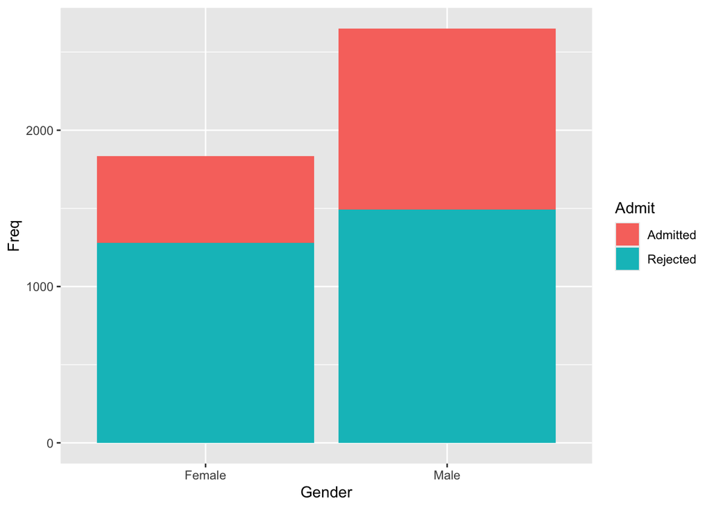

```r
# Using GGplot create an appropriate graphic to show the university-level Admissions. (Hint: Female and male applications admitted and rejected (stacked bar plot (2 bars), admitted and rejected broken down by % male/female.)

p = ggplot(admissions, aes(x = Gender, y = Freq, fill = Admit)) +
  geom_bar(position = "stack", stat = "identity")

p
```

2. Assume admissions are conducted at the department level. Create an appropriate graphic to show the department level Admissions. (use Original_Admissions_Data.csv). (Hint: Let’s look at %male/female for admitted and rejected applicants by department.)

```r
setwd("~/Mason/2026/STAT-515-002/homework/hw1/")
orig_admissions = read.csv("Original_Admissions_Data.csv", header = TRUE)

str(orig_admissions) # View the structure of the new data
```

```
## 'data.frame':    6 obs. of  5 variables:
##  $ Dept           : chr  "A" "B" "C" "D" ...
##  $ Male_Admitted  : int  512 313 120 138 53 22
##  $ Male_Rejected  : int  313 207 205 279 138 351
##  $ Female_Admitted: int  89 17 202 131 94 24
##  $ Female_Rejected: int  19 8 391 244 299 317
```

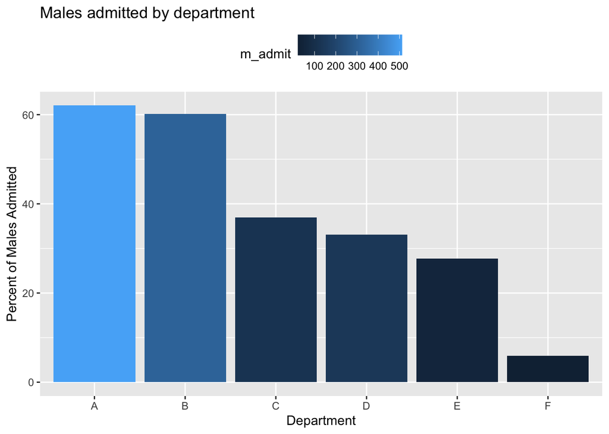

```r
# 'data.frame': 6 obs. of  5 variables:
#  $ Dept           : chr  "A" "B" "C" "D" ...
#  $ Male_Admitted  : int  512 313 120 138 53 22
#  $ Male_Rejected  : int  313 207 205 279 138 351
#  $ Female_Admitted: int  89 17 202 131 94 24
#  $ Female_Rejected: int  19 8 391 244 299 317


# First create the male and female acceptance rates as a vector
m_admit = orig_admissions$Male_Admitted
m_reject = orig_admissions$Male_Rejected
f_admit = orig_admissions$Female_Admitted
f_reject = orig_admissions$Female_Rejected
m_admit_percent = c(m_admit / (m_admit + m_reject) * 100)
f_admit_percent = c(f_admit / (f_admit + f_reject) * 100)

# Print the vectors to verify they look like percents and for accuracy
# m_admit_percent # 62.060606 60.192308 36.923077 33.093525 27.748691  5.898123
# f_admit_percent # 82.407407 68.000000 34.064081 34.933333 23.918575  7.038123


m_admit_by_dep = ggplot(orig_admissions, aes(x = Dept, y = m_admit_percent, fill = m_admit)) +
  geom_bar(position = "stack", stat = "identity") +
  labs(title = "Males admitted by department",
              x = "Department",
              y = "Percent of Males Admitted") +
  theme(legend.position = "top")


f_admit_by_dep = ggplot(orig_admissions, aes(x = Dept, y = f_admit_percent, fill = f_admit)) +
  geom_bar(position = "stack", stat = "identity") +
  labs(title = "Females admitted by department",
       x = "Department",
       y = "Percent of Female Admitted") +
  theme(legend.position = "top")

m_admit_by_dep
```

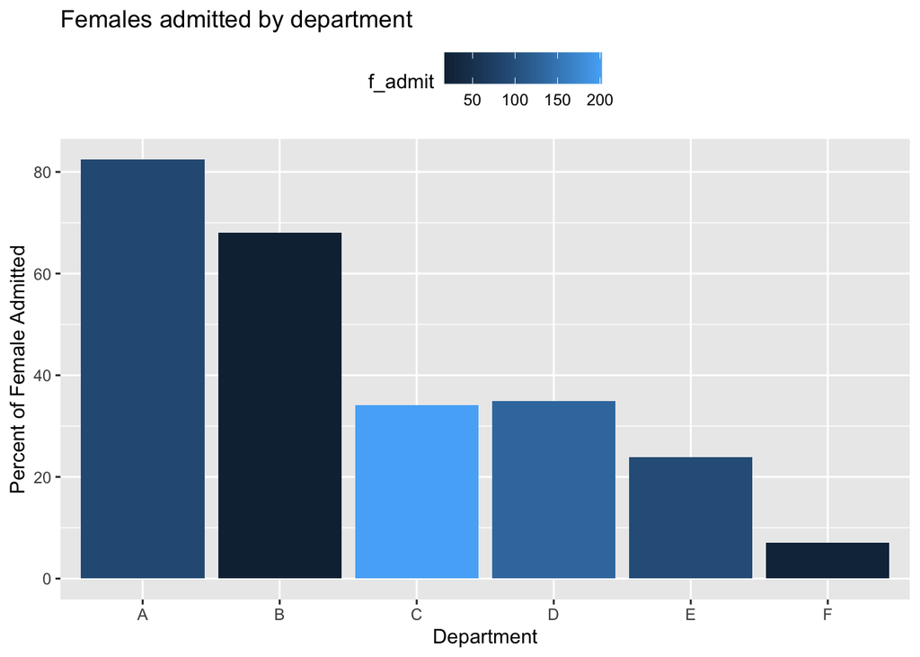

```r
f_admit_by_dep
```

```r
# overall_plot = ggplot(orig_admissions, aes(x = Dept, y = , fill = admissions$Freq))
```

3. Are admissions gender biased? What other factors could influence admission rates? Discuss.

I see a small bias on both Department “A” and Department “B”, Females are more likely to be admitted than males in these department. Department “A” has a higher bias than department “B”. This is in contrast to the original plot in that overall, it seems that females are rejected much higher rate than males, however the first chart leaves out the fact that males are much more likely to apply than females. Overall as a percent of the total population of males or females the have about the same admittion rates across each department with the exception of department A”.

#### Question 2:

The data set used, represents gene expression data for multiple samples. Use `gene expression.csv` for this question.

1. Create a scatter plot representing gene expression of “sampleB” on the X-axis and “sampleH” on the Y-axis. What kind of relationship do you observe?

```r
df = read.csv("gene\ expression.csv")


# Display basic info about the data
cat("\nColumn names:\n")
```

```
##
## Column names:
```

```r
print(colnames(df))
```

```
## [1] "GeneName" "sampleA"  "sampleB"  "sampleC"  "sampleD"  "sampleE"  "sampleF"
## [8] "sampleG"  "sampleH"
```

```r
cat("\nFirst few rows:\n")
```

```
##
## First few rows:
```

```r
print(head(df))
```

```
##        GeneName   sampleA   sampleB   sampleC   sampleD   sampleE   sampleF
## 1 A630034I12Rik  7.632239  8.232005  7.987181  8.172056  8.129552  7.891941
## 2         Kat6b  6.111268  6.229767  6.141933  6.088197  6.107645  6.251614
## 3          Hypm  7.595844  7.394970  7.324830  7.686024  7.174572  7.693701
## 4 A_55_P2148744 13.893641 13.611240 14.154910 13.476677 13.354619 14.157809
## 5        Prima1  6.105578  6.019015  6.074887  6.194815  5.994727  6.123868
## 6 4930573O21Rik  6.097406  6.050446  6.193380  6.130627  6.144257  6.112575
##     sampleG   sampleH
## 1  7.996210  8.057062
## 2  6.056442  6.145633
## 3  7.637656  6.427675
## 4 13.920268 14.431988
## 5  5.973928  6.125203
## 6  6.263766  6.208990
```

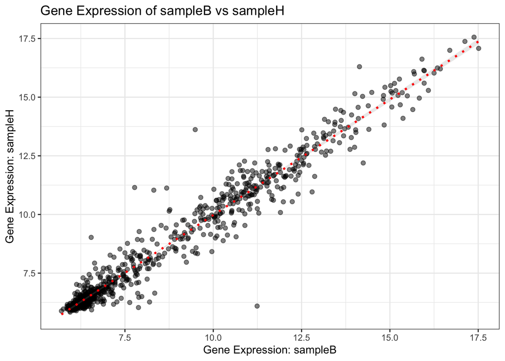

```r
# Extract sampleB and sampleH data
sampleB = df$sampleB
sampleH = df$sampleH



# Create a scatter plot
p = ggplot(df, aes(x = sampleB, y = sampleH)) +
  geom_point(alpha = 0.5, size = 1.75, color = "black") +
  geom_smooth(method = "lm", color = "red", linetype = "dotted", se = TRUE, alpha = .2) +
  labs(
    title = "Gene Expression of sampleB vs sampleH",
    x = "Gene Expression: sampleB",
    y = "Gene Expression: sampleH"
  ) +
  theme_bw()

# Display the plot
p
```

Discussion: The plot shows a strong positive linear relationship between ‘sampleB’ and ‘sampleH’ which may indicate that they will respond in a similar way to treatment. The relationship is so close that they may have come from the same experiment or trial.

2. Add a column to the data frame, according to the following conditions:
   - Name the new column as “expre_limit”.
   - If the expression of a gene is > 13 in both sampleB and sampleH, set to the value in “expre_limits” to “high”.
   - If the expression of a gene is < 6 in both sampleB and sampleH, set it to “low”.
   - If different, set it to “normal”.

```r
library(dplyr)
# Create a new data frame
df2 = read.csv("gene\ expression.csv")

# isolate sample data for comparison
sampleB2 = df2$sampleB
sampleH2 = df2$sampleH

# Add a new column 'expre_limit' by comparing sampleB2 and sampleH2
df2 = df2 %>%
  mutate(expre_limits = case_when(
    sampleB2 > 13 & sampleH2 > 13 ~ "high",
    sampleB2 < 6 & sampleH2 < 6 ~ "low",
    TRUE ~ "normal" # Default value if none of the above match
  ))


# Verify that the new column was created correctly
cat("\nColumn names:\n")
```

```
##
## Column names:
```

```r
print(colnames(df2))
```

```
##  [1] "GeneName"     "sampleA"      "sampleB"      "sampleC"      "sampleD"
##  [6] "sampleE"      "sampleF"      "sampleG"      "sampleH"      "expre_limits"
```

```r
cat("\nFirst few rows of the new dataframe:\n")
```

```
##
## First few rows of the new dataframe:
```

```r
print(head(df2))
```

```
##        GeneName   sampleA   sampleB   sampleC   sampleD   sampleE   sampleF
## 1 A630034I12Rik  7.632239  8.232005  7.987181  8.172056  8.129552  7.891941
## 2         Kat6b  6.111268  6.229767  6.141933  6.088197  6.107645  6.251614
## 3          Hypm  7.595844  7.394970  7.324830  7.686024  7.174572  7.693701
## 4 A_55_P2148744 13.893641 13.611240 14.154910 13.476677 13.354619 14.157809
## 5        Prima1  6.105578  6.019015  6.074887  6.194815  5.994727  6.123868
## 6 4930573O21Rik  6.097406  6.050446  6.193380  6.130627  6.144257  6.112575
##     sampleG   sampleH expre_limits
## 1  7.996210  8.057062       normal
## 2  6.056442  6.145633       normal
## 3  7.637656  6.427675       normal
## 4 13.920268 14.431988         high
## 5  5.973928  6.125203       normal
## 6  6.263766  6.208990       normal
```

```r
# Source:
# [1] https://rpubs.com/nth-education/dplyr_case_when#:~:text=case_when()%20allows%20us%20to%20add%20multiple%20if_else(),understand%20for%20any%20user%20going%20forward%20:)
# [2] https://www.r-bloggers.com/2023/12/create-new-variables-in-r-with-dplyr/#:~:text=You%20can%20use%20the%20case_when,condition2%20~%20value2%2C%20etc.))
```

3. Color the points of the scatter plot according to the newly created column “expre_limits”. Save that plot in the object “plot1”.

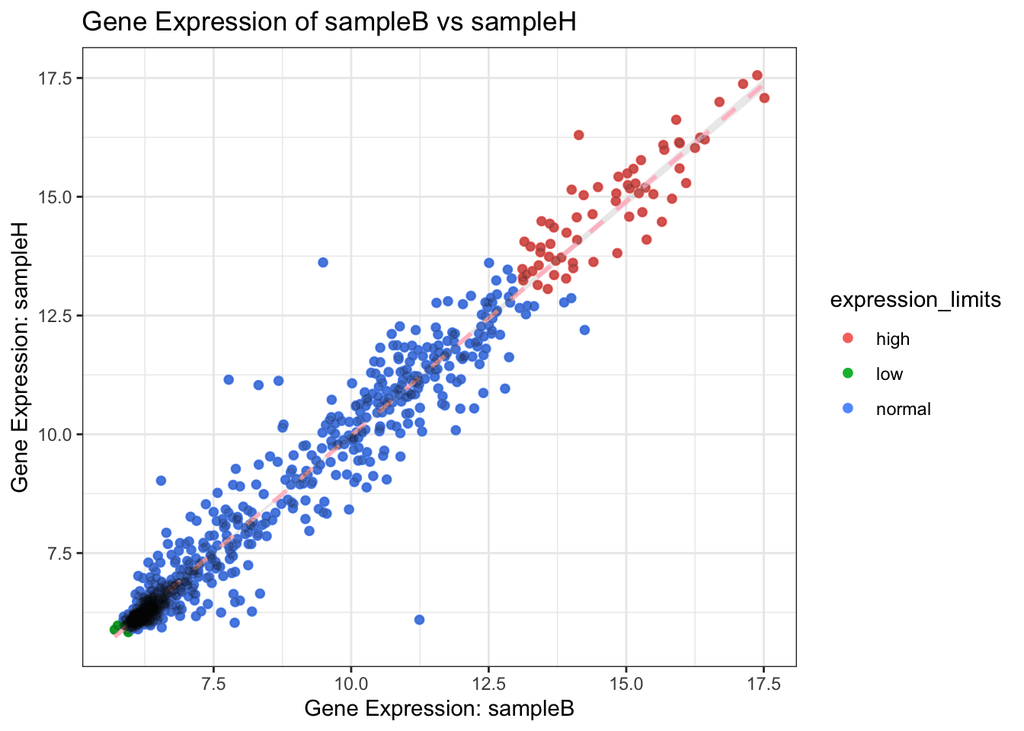

```r
expression_limits = df2$expre_limits

# Create the scatter plot
plot1 = ggplot(df2, aes(x = sampleB2, y = sampleH2)) +
  geom_point(aes(color = expression_limits), size = 1.75) +
  geom_smooth(method = "lm", color = "pink", linetype = "dashed", se = TRUE, alpha = .2) +
  labs(
    title = "Gene Expression of sampleB vs sampleH",
    x = "Gene Expression: sampleB",
    y = "Gene Expression: sampleH"
  ) +
  theme_bw() +
  geom_point(alpha = 1/10) +
  geom_point(alpha = 1/50) +
  geom_point(alpha = 1/100)

# Display the plot
plot1
```

```r
# Source:
# https://rafalab.dfci.harvard.edu/dsbook-part-1/dataviz/ggplot2.html#categories-as-colors
```

4. Rename the legend title as “Expression Limits”.

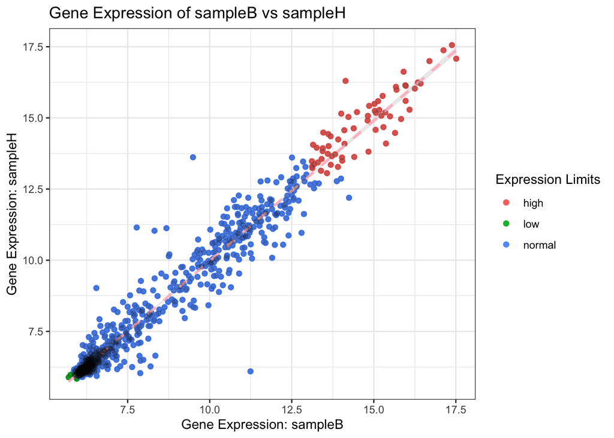

```r
plot1 + labs(color='Expression Limits')
```

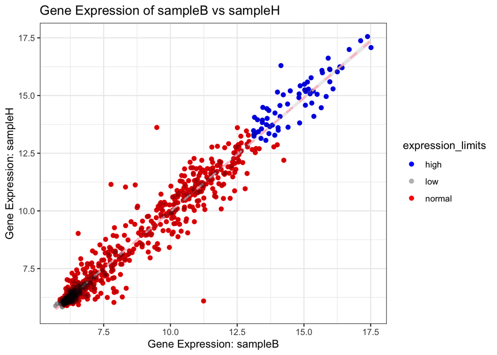

```r
colors_vector = c("blue", "grey", "red")
plot2 = plot1 + scale_color_manual(values = colors_vector)
plot2
```

```r
# Source:
# https://www.sthda.com/english/wiki/ggplot2-colors-how-to-change-colors-automatically-and-manually#:~:text=sp%20%2B%20scale_color_manual(values%3Dc(%22%23999999%22%2C%20%22%23E69F00%22%2C%20%22%2356B4E9%22))
```

6. Produce a bar plot of how many low/normal/high genes are in the column ‘expre_limits’. Save this plot as “plot3”.

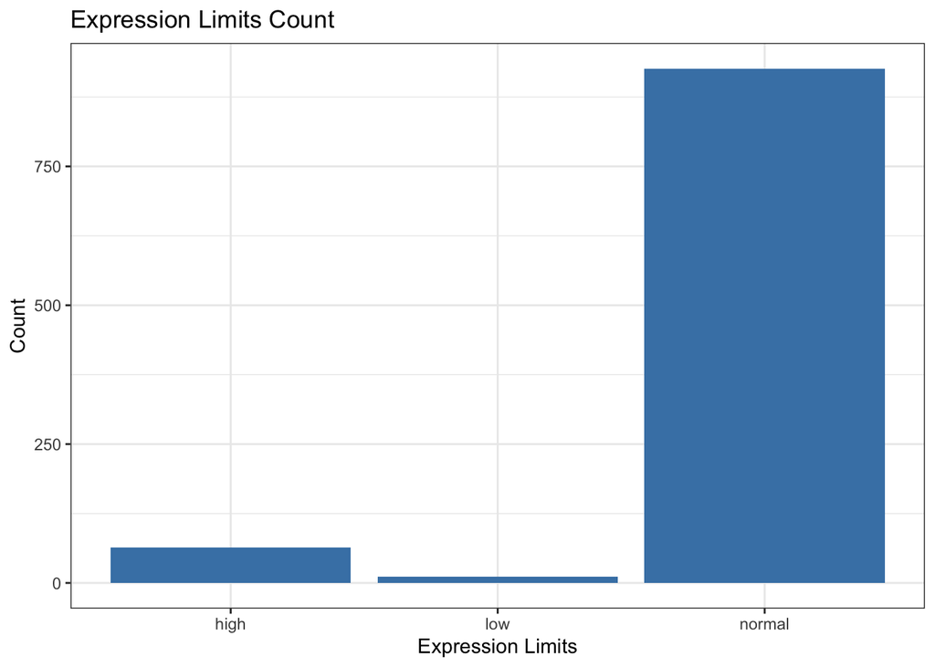

```r
# Crate a count to use for our y axis mapping
library(dplyr)
df2 %>%
  group_by(expre_limits) %>%
  summarize(count = n()) %>%
  {. ->> expression_limits_count}


# Create the plot
plot3 <- ggplot(expression_limits_count, aes(x = expre_limits, y = count)) +
  geom_bar(stat = "identity", fill = "steelblue") +
  labs(title = "Expression Limits Count",
       x = "Expression Limits",
       y = "Count") +
  theme_bw()

# Display the plot
plot3
```

7. To plot3, add an horizontal line at “counts = 250”.

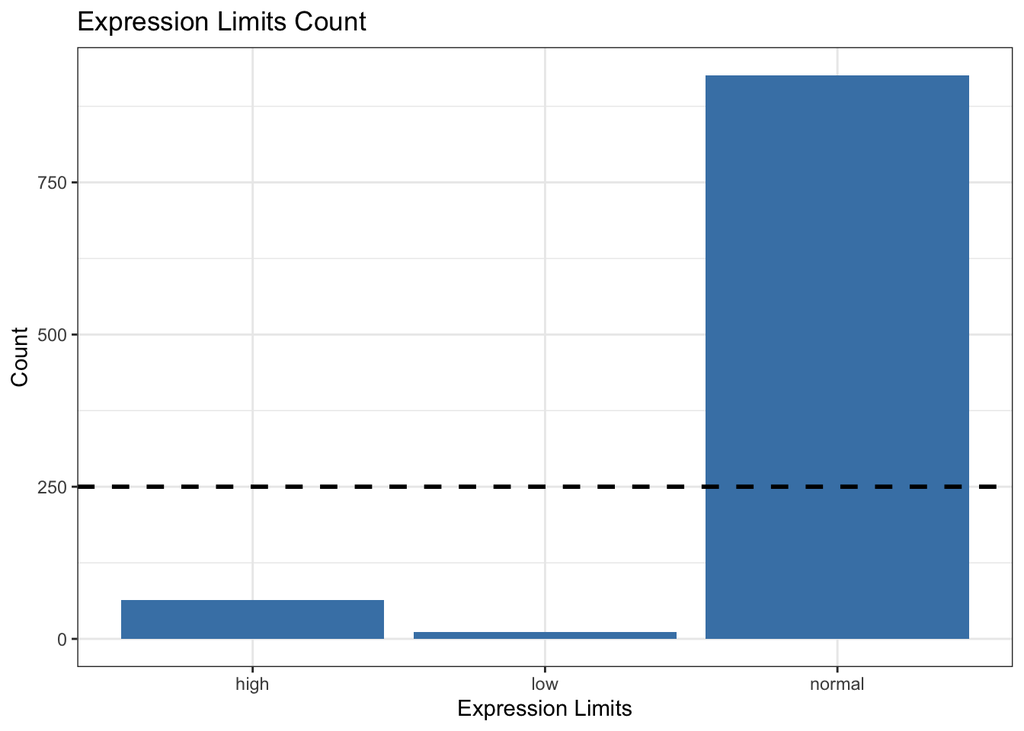

```r
# Add the horizontal line at y-intercept = 250
plot3 + geom_hline(yintercept = 250, color = "black", linetype = "dashed", linewidth = 1)
```

8. Swap the X-axis and the Y-axis of the plot from part 7).

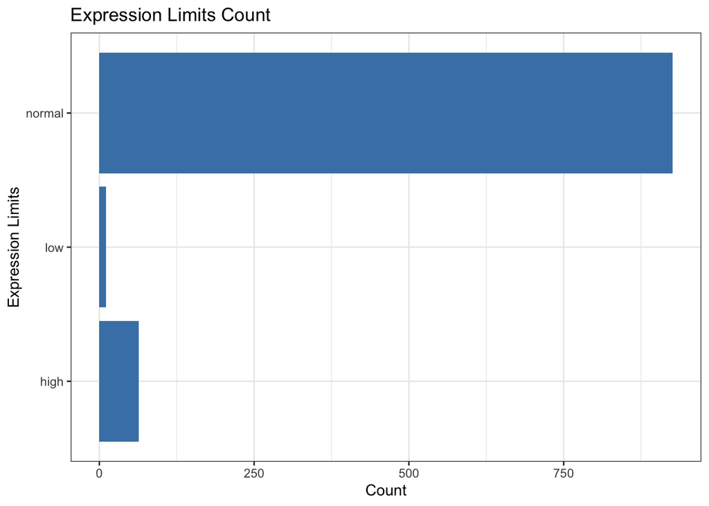

```r
# Use coord_flip()
plot4 = plot3 + coord_flip()
plot4
```

```r
# Source:
# https://www.sthda.com/english/wiki/ggplot2-rotate-a-graph-reverse-and-flip-the-plot#:~:text=reverse%20the%20axes-,Horizontal%20plot%20%3A%20coord_flip(),-Box%20plot%20%3A
```

#### Question 3:

Titanic data set from `Kaggle.com` is used for this example. Please use `titanic.csv` for this question.

Description of the data set as follows:

[figure not shown]

1. Is there a relationship between the age of the passenger and the passenger fare? Explore this by constructing a scatter plot.

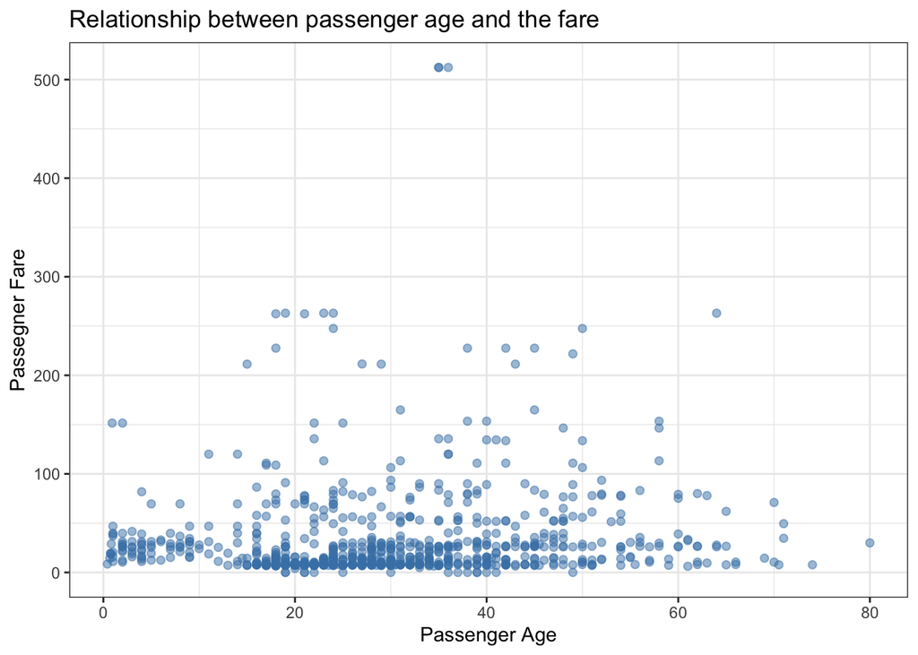

```r
# Set working directory and load the data into a df object
setwd("~/Mason/2026/STAT-515-002/homework/hw1/")
titanic_df = read.csv("titanic.csv")

# Summary for reference
# str(titanic_df)
# 'data.frame': 887 obs. of  8 variables:
#  $ Survived               : int  0 1 1 1 0 0 0 0 1 1 ...
#  $ Pclass                 : int  3 1 3 1 3 3 1 3 3 2 ...
#  $ Name                   : chr  "Mr. Owen Harris Braund" "Mrs. John Bradley (Florence Briggs Thayer) Cumings" "Miss. Laina Heikkinen" "Mrs. Jacques Heath (Lily May Peel) Futrelle" ...
#  $ Sex                    : chr  "male" "female" "female" "female" ...
#  $ Age                    : num  22 38 26 35 35 27 54 2 27 14 ...
#  $ Siblings.Spouses.Aboard: int  1 1 0 1 0 0 0 3 0 1 ...
#  $ Parents.Children.Aboard: int  0 0 0 0 0 0 0 1 2 0 ...
#  $ Fare                   : num  7.25 71.28 7.92 53.1 8.05 ...


# Create the plot include relevent information
titanic_plot = ggplot(titanic_df, aes(x = Age, y = Fare)) +
  geom_point(alpha = 0.5, size = 1.75, color = "steelblue") +
  labs(
    title = "Relationship between passenger age and the fare",
    x = "Passenger Age",
    y = "Passegner Fare"
  ) +
  theme_bw()

# View the plot for analysis
titanic_plot
```

Discussion: I do not see a strong correlation between the passenger age and fare in the data.

2. Color the points from question 1 by Pclass. Remember that Pclass is a proxy for socioeconomic status.

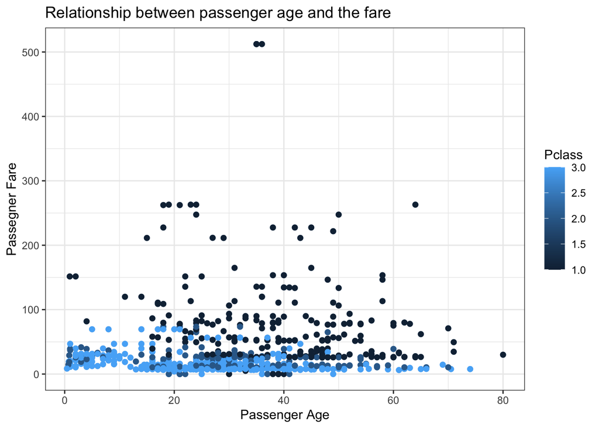

```r
titanic_plot_1 = titanic_plot + geom_point(aes(color = Pclass), size = 1.75)
titanic_plot_1
```

3. Manually scale the colors in question 4. 1st class = red, 2nd class = purple, 3rd class = seagreen. Also change the legend labels (1 = 1st Class, 2 = 2nd Class, 3 = 3rd Class).

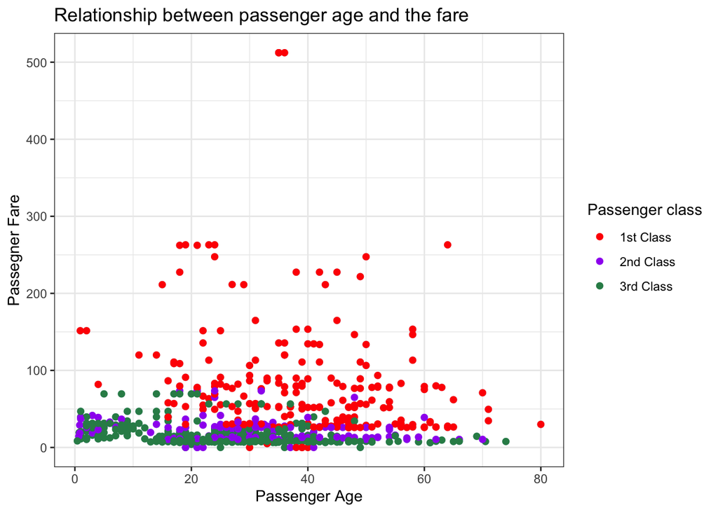

```r
# titanic_plot + geom_point(aes(color = Pclass), size = 1.75)

legend_colors = c("1" = "red", "2" = "purple", "3" = "seagreen")
# legend_lable = ""


titanic_plot_2 = titanic_plot +
  geom_point(aes(color = as.factor(Pclass)), size = 1.75) +
  scale_color_manual(
    values = legend_colors,
    labels = c("1" = "1st Class", "2" = "2nd Class", "3" = "3rd Class"),
    name = "Passenger class"
    )


titanic_plot_2
```

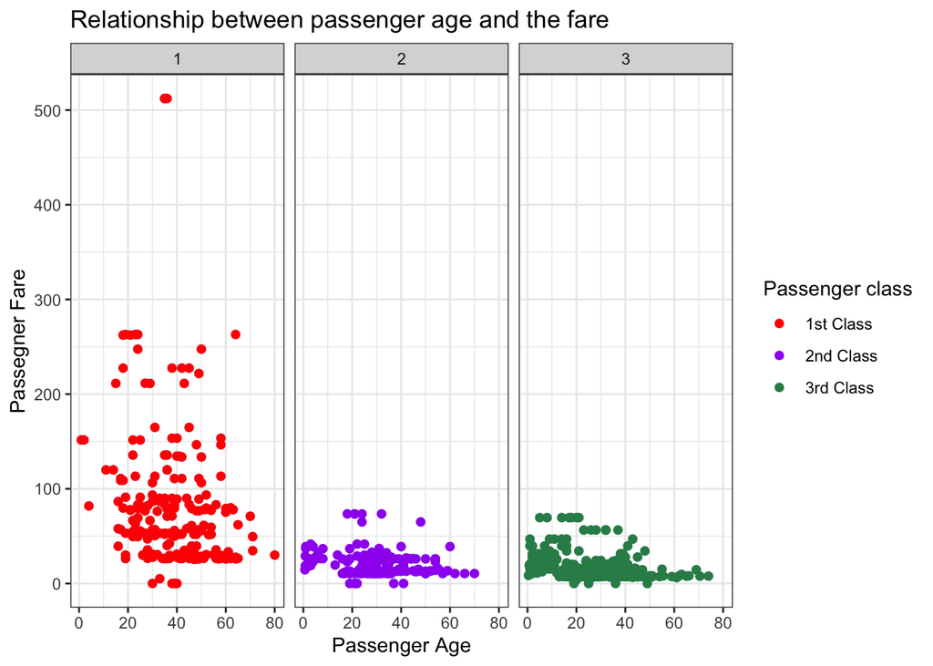

```r
titanic_plot_3 = titanic_plot_2 + facet_wrap("Pclass")
titanic_plot_3
```

```r
# Source: https://ggplot2-book.org/facet.html#sec-facet-wrap
```

5. Plot the number of passengers (a simple count) that survived by ticket class.

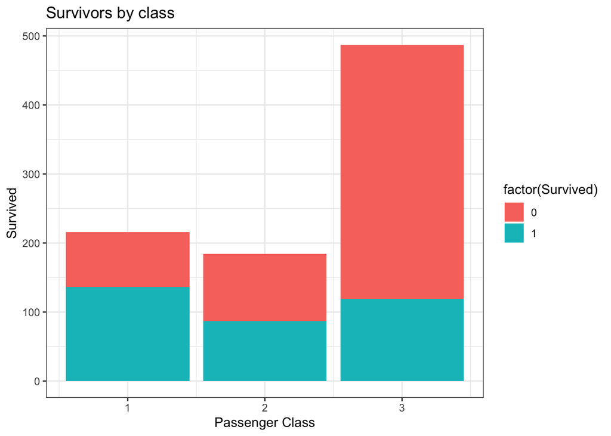

```r
survival_by_class = ggplot(titanic_df, aes(Pclass, fill = factor(Survived))) +
  geom_bar(position = "stack", stat = "count") +
  labs(
    title = "Survivors by class",
    x = "Passenger Class",
    y = "Survived"
  ) +
  theme_bw()

survival_by_class
```

```r
# Source: https://chanida-limt.medium.com/titanic-survival-prediction-c421aac8da32#:~:text=As%20the%20data%20described%20above%2C%20titanic%20passengers%20had%20divided%20into%203%20classes%20and%20each%20class%20has%20its%20own%20position%20on%20the%20Titanic.
```